# The effect of age, the number of ApoE4 allele copies, or brain volume on Alzheimer’s disease diagnosis

Juliana, Carol, Christopher, Jake

7/29/2021

```r
#install the data set
adni<-read.table("ADNI.txt",header=T)
```

## Research Questions

Give an overview of data description: data collection methods, describe how the sample was identified, a brief summary of the variables analyzed. State the goal or research questions in the project.

The Alzheimer’s Disease Neuroimaging Initiative (ADNI) is a longitudinal study that began in 2005. The ADNI data set we use has information on 276 volunteers aged over 55 who are either healthy (the control group) or diagnosed with Alzheimer’s Disease (according to the website http://adni.loni.usc.edu/about/).

The data set contains 7 variables:

1. DX tells us whether each individual is diagnosed with Alzheimer’s disease or not. It is a categorical variable with 3 levels: AD (Alzheimer’s disease), MCI (mild cognitive impairment), and Normal (normal cognitive function). We choose it as the response variable.
2. AGE tells us about each individual’s age in years. It is a quantitative variable. We choose this as one of the explanatory variables because older individuals may have more likelihood to develop Alzheimer’s disease.
3. APOE4 tells us how many copies of Apolipoprotein E (APOE) allele each individual has. It is a categorical variable with 3 levels: 0 (no copies of the ApoE4 allele), 1 (one copy of the ApoE4 allele), and 2 (two copies of the ApoE4 allele). We choose this as one of the explanatory variables because the ApoE4 gene on chromosome 19 has variants associated with a high risk of Alzheimer’s disease. Individuals who have the genes could have the disease.
4. GENDER tells us about each individual’s gender.
5. MMSE tells us how well each individual does on the Mini Mental State Exam (a 30-question assessment commonly used to assess cognitive impairment). The score is out of 30, and lower scores indicate more cognitive impairment.
6. adas tells us about how good each individual do on Alzheimer’s Disease Assessment Scale (a more comprehensive measure of cognitive impairment). Larger scores indicate greater dysfunction.
7. WholeBrain tells us about each individual’s brain volume in mm^3. It is a quantitative variable. We chose this as one of the explanatory variables because the differences in brain sizes could make individuals more susceptible to the diseases.

Our goal is to define the effect of age, the number of ApoE4 allele copies, or brain volume on Alzheimer’s disease diagnosis.

## Cleaning Data

Show all R codes about re-coding or re-classifying any variables, removal or changing of implausible values, any exclusion criteria implemented, dealing with missing data.

```r
#re-classify DX to a dichotomous categorical variable
table(adni$DX)
```

```
##
##     AD    MCI Normal
##     54    128     94
```

```r
adni$DX2<-adni$DX
adni$DX2[adni$DX=="AD"|adni$DX=="MCI"]<-"Yes"
adni$DX2[adni$DX=="Normal"]<-"No"
table(adni$DX2)
```

```
##
##  No Yes
##  94 182
```

```r
#AGE, APOE4, and WholeBrain do not have implausible values or missing data.
```

## Summarizing Data

Show all R codes about summarizing variables.

```r
library(mosaic)
#descriptive statistics of AGE
favstats(adni$AGE)
```

```
##   min   Q1 median     Q3  max     mean       sd   n missing
##  55.6 69.3   73.6 78.025 90.9 73.58261 6.994839 276       0
```

```r
favstats(adni$AGE[adni$DX2=="Yes"])
```

```
##   min Q1 median     Q3  max     mean       sd   n missing
##  55.6 68   73.6 78.175 90.9 73.21758 7.538961 182       0
```

```r
favstats(adni$AGE[adni$DX2=="No"])
```

```
##   min    Q1 median     Q3  max     mean       sd  n missing
##  59.8 70.75  73.45 77.075 89.6 74.28936 5.770363 94       0
```

```r
#descriptive statistics of APOE4
addmargins(table(adni$APOE4,adni$DX2)) #Frequencies
```

```
##
##        No Yes Sum
##   0    62  75 137
##   1    28  81 109
##   2     4  26  30
##   Sum  94 182 276
```

```r
prop.table(table(adni$APOE4,adni$DX2),margin=1) #Yes and No groups proportions
```

```
##
##            No       Yes
##   0 0.4525547 0.5474453
##   1 0.2568807 0.7431193
##   2 0.1333333 0.8666667
```

```r
prop.table(table(adni$APOE4)) #Overall proportion
```

```
##
##         0         1         2
## 0.4963768 0.3949275 0.1086957
```

```r
#descriptive statistics of WholeBrain
favstats(adni$WholeBrain)
```

```
##     min       Q1  median      Q3     max    mean     sd   n missing
##  754507 936889.5 1020000 1102500 1440000 1021145 112039 276       0
```

```r
favstats(adni$WholeBrain[adni$DX2=="Yes"])
```

```
##     min       Q1  median      Q3     max    mean       sd   n missing
##  754507 927542.5 1010000 1100000 1440000 1012598 118419.5 182       0
```

```r
favstats(adni$WholeBrain[adni$DX2=="No"])
```

```
##     min       Q1  median      Q3     max    mean       sd  n missing
##  790001 968721.8 1040000 1110000 1230000 1037694 96985.03 94       0
```

## One table of summary

Table 1: Descriptive statistics and p-values of age, the number of ApoE4 allele copies, and brain volume on Alzheimer’s disease diagnosis

|  | Overall(n=276) | Yes Group(n=182) | No Group(n=94) | p-value |
| --- | --- | --- | --- | --- |
| Age | 73.58+/-6.99 | 73.22+/-7.54 | 74.29+/-5.77 | 0.2283 |
| # ApoE4 allele (0) | 49.64% (137) | 54.74% (75) | 45.26% (62) |  |
| (1) | 39.49% (109) | 74.31% (81) | 25.69% (28) | 0.0002 |
| (2) | 10.87% (30) | 86.67% (26) | 13.33% (4) |  |
| Brain volume (mm^3) | 1.02e6+/-1.12e5 | 1.01e6+/-1.18e5 | 1.04e6+/-9.70e4 | 0.0778 |

Abbreviation explained:

“# ApoE4 allele” means the number of ApoE4 allele copies. “(0)” means no copies of the ApoE4 allele. “(1)” means one copy of the ApoE4 allele. “(2)” means two copies of the ApoE4 allele. “Brain volume (mm^3)” means brain volume is measured in mm^3.

## Statistical significance tests

Show all R codes of significance tests and write down tests details and fill p-value in the above table.

1. We will conduct a 2 sample t-test on AGE (quantitative) and DX2 (dichotomous categorical).

Define parameter of interest: μy = the true mean of age in the “Yes” group (who is diagnosed with Alzheimer’s) μn = the true mean of age in the “No” group (who is not diagnosed with Alzheimer’s)

H0: There is no association between age and diagnosis of Alzheimer’s disease (μy = μn). HA: There is an association between age and diagnosis of Alzheimer’s disease (μy ≠ μn).

Randomization: The individuals are volunteers, so this condition is not satisfied and the inference may be biased. Independence: The two groups and observations are independent. Normality: Though the histogram for each group is not normally distributed, both groups’ sample sizes are larger than 30 (“Yes” group: n=182>30, “No” group: n=94>30). So this condition is satisfied.

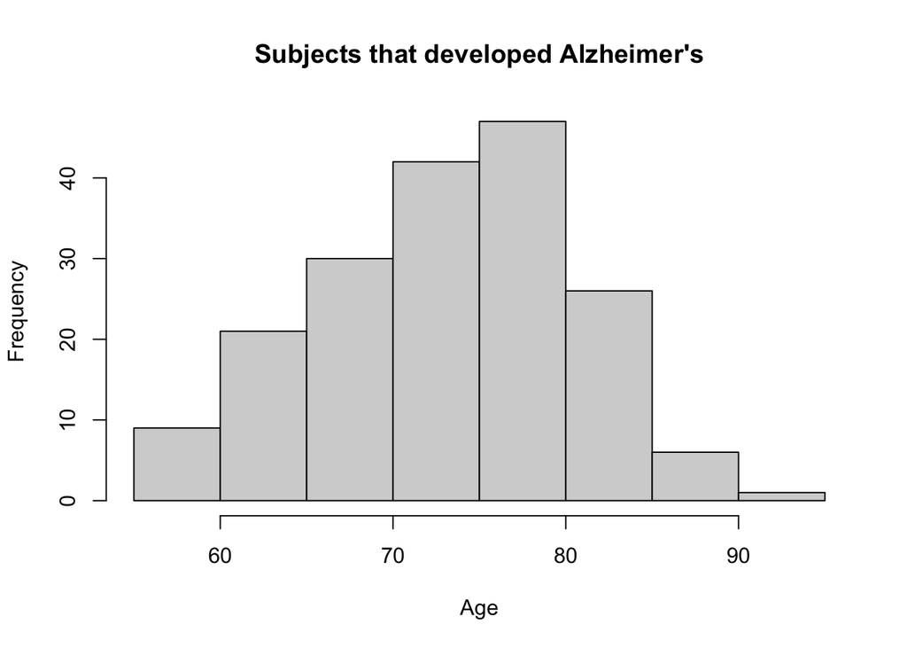

```r
#Check the condition for normality
hist(adni$AGE[adni$DX2=="Yes"],main="Subjects that developed Alzheimer's",xlab="Age")
```

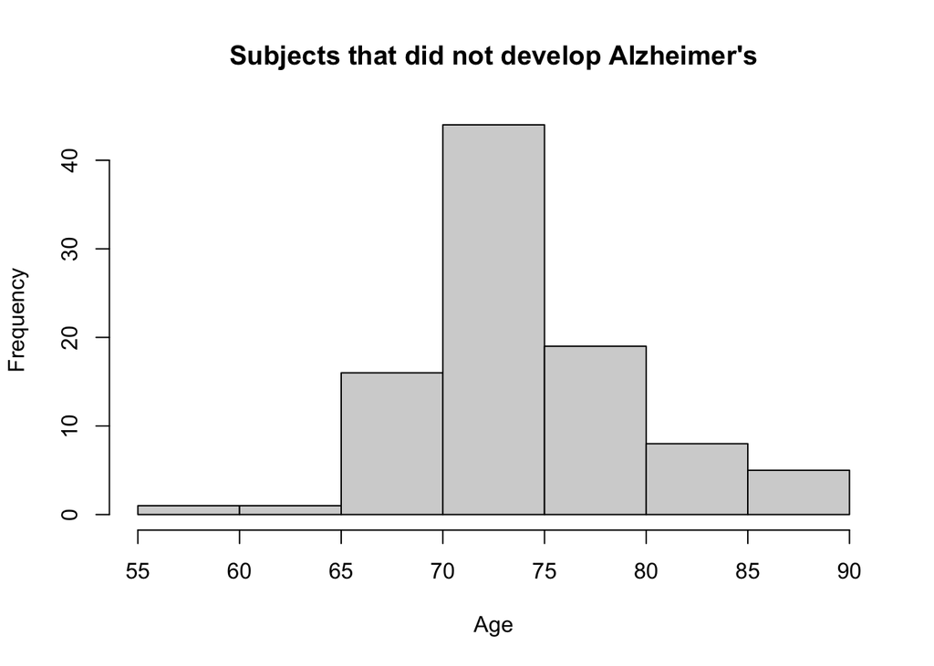

```r
hist(adni$AGE[adni$DX2=="No"],main="Subjects that did not develop Alzheimer's",xlab="Age")
```

```r
#The histogram for each group is not normally distributed.

#Equal variance or unequal variance?
sd(adni$AGE[adni$DX2=="Yes"]) #sy=7.538961
```

```
## [1] 7.538961
```

```r
sd(adni$AGE[adni$DX2=="No"]) #sn=5.770363
```

```
## [1] 5.770363
```

```r
#Since sy<2*sn, we assume equal variance.

t.test(adni$AGE~adni$DX2,var.equal=TRUE)
```

```
##
##  Two Sample t-test
##
## data:  adni$AGE by adni$DX2
## t = 1.2074, df = 274, p-value = 0.2283
## alternative hypothesis: true difference in means between group No and group Yes is not equal to 0
## 95 percent confidence interval:
##  -0.6758212  2.8193798
## sample estimates:
##  mean in group No mean in group Yes
##          74.28936          73.21758
```

```r
#t=1.2074, df=274, p-value=0.2283
```

Since the p-value is greater than α=0.05, we fail to reject H0. The data do not provide convincing evidence that age and diagnosis of Alzheimer’s disease are associated.

2. We will conduct a chi-square test for independence on APOE4 (categorical with 3 categories) and DX2 (dichotomous categorical).

H0: The number of ApoE4 allele copies is independent of whether the individual is diagnosed with Alzheimer’s Disease. HA: The number of ApoE4 alleles copies is dependent on whether the individual is diagnosed with Alzheimer’s Disease.

1. randomization (The individuals are volunteers, so this condition is not satisfied and the inference may be biased)
2. independence (no relation between subjects in each group, so this condition is satisfied)
3. expected counts (According to the code performed below, all expected cell counts are at least 5, so this condition is satisfied for valid inference)

```r
#Check the condition for expected counts
apoe4.dx.test<-chisq.test(adni$APOE4,adni$DX2)
apoe4.dx.test$expected
```

```
##           adni$DX2
## adni$APOE4       No      Yes
##          0 46.65942 90.34058
##          1 37.12319 71.87681
##          2 10.21739 19.78261
```

```r
#All expected cell counts are at least 5.

chisq.test(adni$APOE4,adni$DX2)
```

```
##
##  Pearson's Chi-squared test
##
## data:  adni$APOE4 and adni$DX2
## X-squared = 16.786, df = 2, p-value = 0.0002264
```

```r
#x^2=16.786, df=2, p-value=0.0002264
```

Since the p-value is much smaller than α=0.05, we reject H0. The data provide convincing evidence that the number of ApoE4 allele copies and Alzheimer’s diagnosis are associated.

3. We will conduct a 2 sample t-test on WholeBrain (quantitative) and DX2 (dichotomous categorical).

Define parameter of interest: μy = the true mean of brain volume in the “Yes” group (who is diagnosed with Alzheimer’s) μn = the true mean of brain volume in the “No” group (who is not diagnosed with Alzheimer’s)

H0: There is no association between brain volume and diagnosis of Alzheimer’s disease (μy = μn). HA: There is an association between brain volume and diagnosis of Alzheimer’s disease (μy ≠ μn).

Random: The individuals are volunteers, so this condition is not satisfied and the inference may be biased. Independence: We could assume independence between groups and observations. Normality: Though the histogram for each group is not normally distributed, both groups’ sample sizes are larger than 30 (“Yes” group: n=182>30, “No” group: n=94>30). So this condition is satisfied.

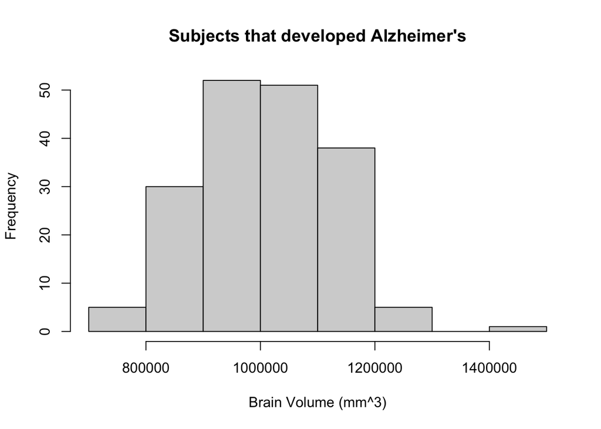

```r
#Checking the condition for normality
hist(adni$WholeBrain[adni$DX2=="Yes"],main="Subjects that developed Alzheimer's",xlab="Brain Volume (mm^3)")
```

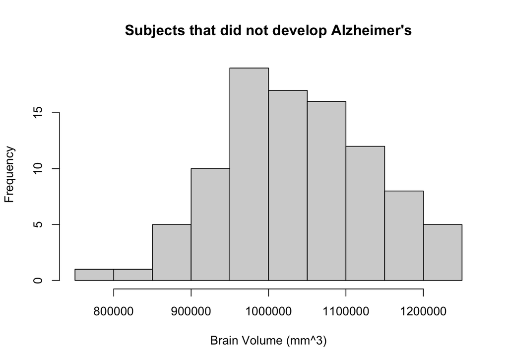

```r
hist(adni$WholeBrain[adni$DX2=="No"],main="Subjects that did not develop Alzheimer's",xlab="Brain Volume (mm^3)")
```

```r
#The histogram for each group is not normally distributed.

#Equal variance or unequal variance?
sd(adni$WholeBrain[adni$DX2=="Yes"]) #sy=118419.5
```

```
## [1] 118419.5
```

```r
sd(adni$WholeBrain[adni$DX2=="No"]) #sn=96985.03
```

```
## [1] 96985.03
```

```r
#Since sy<2*sn, we assume equal variance.

t.test(adni$WholeBrain~adni$DX2,var.equal=TRUE)
```

```
##
##  Two Sample t-test
##
## data:  adni$WholeBrain by adni$DX2
## t = 1.7703, df = 274, p-value = 0.07778
## alternative hypothesis: true difference in means between group No and group Yes is not equal to 0
## 95 percent confidence interval:
##  -2811.493 53002.891
## sample estimates:
##  mean in group No mean in group Yes
##           1037694           1012598
```

```r
#t=1.7703, df=274, p-value=0.07778
```

Since the p-value is greater than α=0.05, we fail to reject H0. The data do not provide convincing evidence that brain volume and diagnosis of Alzheimer’s disease are associated.

## Summary of the project

Draw conclusion of your tests and analysis results, discuss the limitations of your analysis and suggestion back to the population.

The ADNI data set we use comes from a longitudinal study that began in 2005. It has information on 276 volunteers aged over 55 who are either healthy or diagnosed with Alzheimer’s Disease. Our goal is to define the effect of age, the number of ApoE4 allele copies, or brain volume on Alzheimer’s disease diagnosis.

A 2-sample t-test is performed on age and diagnosis of Alzheimer’s disease. The mean age of people who have Alzheimer’s is 73.22 years old and of people who don’t have Alzheimer’s is 74.29 years old. The result of the test is not statistically significant since the p-value is 0.2283, which is greater than 0.05.

A 2-sample t-test is performed on brain volume and diagnosis of Alzheimer’s disease. The average brain volume of people who develop Alzheimer’s is 1.01e6 mm^3 and of people who don’t is 1.04e6 mm^3. The result of the test is not statistically significant since the p-value is 0.0778, which is greater than 0.05.

If interested, a further test could be conducted on the number of ApoE4 allele copies and diagnosis of Alzheimer’s disease diagnosis to determine which number of allele copies have the most effect on diagnosis. But essentially, any associations between variables are not generalizable to the broader population.